# exploratory_analysis

## Pisa Data 2012

This is an analysis for the PISA 2012 dataset for data analyst nanodegree of Udacity. In this analysis we are going to explore and clean the original PISA dataset and in the next notebook, we will present the findings.

The PISA database contains the full set of responses from individual students, school principals and parents. PISA is a survey of students' skills and knowledge as they approach the end of compulsory education. It is not a conventional school test. Rather than examining how well students have learned the school curriculum, it looks at how well prepared they are for life beyond school.

Around 510,000 students in 65 economies took part in the PISA 2012 assessment of reading, mathematics and science representing about 28 million 15-year-olds globally. Of those economies, 44 took part in an assessment of creative problem solving and 18 in an assessment of financial literacy.

### What is/are the main feature(s) of interest in your dataset?

- In this dataset we will explore the scores in math, science, reading and average scores of the students.
- Also we will explore what the scores depend on.

### What features in the dataset do you think will help support your investigation into your feature(s) of interest?

In this analysis we will use the following features of the dataset:

- Country
- Gender
- late_for_sch
- possessions_room
- possessions_literature
- math_imprtnt_future_student
- math_imprtnt_future_parents
- possessions_computer
- class_size
- teach_diff_task_to_diff_stud
- teach_gives_feedback
- stud_belong_at_sch
- stud_give_up_easy
- math_score
- reading_score
- science_score
- ave_score
- possessions_litterature

Most of the variables are categorical.  
Those variables will help us with the analysis.

```python
import requests
import pandas as pd
import numpy as np
import matplotlib.pyplot as plt
import seaborn as sns

%matplotlib inline
```

```python
df = pd.read_csv('pisa2012.csv', sep=',',  encoding='latin-1')
```

```python
df['CNT']
```

```
0         Albania
1         Albania
2         Albania
3         Albania
4         Albania
           ...
485485    Vietnam
485486    Vietnam
485487    Vietnam
485488    Vietnam
485489    Vietnam
Name: CNT, Length: 485490, dtype: object
```

As we can see, this dataset is really big. In order to work on it we will need to drop columns and keep the ones we are interested in.

```python
df.shape
```

```
(485490, 636)
```

```python
df.CNT.unique()
```

```
array(['Albania', 'United Arab Emirates', 'Argentina', 'Australia',
       'Austria', 'Belgium', 'Bulgaria', 'Brazil', 'Canada',
       'Switzerland', 'Chile', 'Colombia', 'Costa Rica', 'Czech Republic',
       'Germany', 'Denmark', 'Spain', 'Estonia', 'Finland', 'France',
       'United Kingdom', 'Greece', 'Hong Kong-China', 'Croatia',
       'Hungary', 'Indonesia', 'Ireland', 'Iceland', 'Israel', 'Italy',
       'Jordan', 'Japan', 'Kazakhstan', 'Korea', 'Liechtenstein',
       'Lithuania', 'Luxembourg', 'Latvia', 'Macao-China', 'Mexico',
       'Montenegro', 'Malaysia', 'Netherlands', 'Norway', 'New Zealand',
       'Peru', 'Poland', 'Portugal', 'Qatar', 'China-Shanghai',
       'Perm(Russian Federation)', 'Florida (USA)', 'Connecticut (USA)',
       'Massachusetts (USA)', 'Romania', 'Russian Federation',
       'Singapore', 'Serbia', 'Slovak Republic', 'Slovenia', 'Sweden',
       'Chinese Taipei', 'Thailand', 'Tunisia', 'Turkey', 'Uruguay',
       'United States of America', 'Vietnam'], dtype=object)
```

```python
#Check the Countries values
df['CNT'].value_counts()
```

```
Mexico                      33806
Italy                       31073
Spain                       25313
Canada                      21544
Brazil                      19204
                            ...
Florida (USA)                1896
Perm(Russian Federation)     1761
Massachusetts (USA)          1723
Connecticut (USA)            1697
Liechtenstein                 293
Name: CNT, Length: 68, dtype: int64
```

```python
#Check if any rows are duplitcated
df.duplicated().any()
```

```
False
```

```python
#Check all the countries values
df['CNT'].value_counts()
```

```
Mexico                      33806
Italy                       31073
Spain                       25313
Canada                      21544
Brazil                      19204
                            ...
Florida (USA)                1896
Perm(Russian Federation)     1761
Massachusetts (USA)          1723
Connecticut (USA)            1697
Liechtenstein                 293
Name: CNT, Length: 68, dtype: int64
```

Student Information

- CNT: Country
- ST04Q01: Gender
- Student Mathematics Scores
- PV1MATH: Overall Mathematics Score Student's Attitude Towards Mathematics

Instrumental Motivation

- ST29Q02: Worthwhile for Work
- ST29Q05: Worthwhile for Career Chances
- ST29Q07: Important for Future Study
- ST29Q08: Helps to Get a Job Math Anxiety

ST42Q01: Worry That It Will Be Difficult ST42Q03: Get Very Tense ST42Q05: Get Very Nervous ST42Q08: Feel Helpless ST42Q10: Worry About Getting Poor Math Self-Concept

ST42Q02: Not Good at Maths ST42Q04: Get Good (Grades) ST42Q06: Learn Quickly ST42Q07: One of Best Subjects ST42Q09: Understand Difficult Work Math Interest

ST29Q01: Enjoy Reading ST29Q03: Look Forward to Lessons ST29Q04: Enjoy Maths ST29Q06: Interested Math Work Ethic

ST46Q01: Homework Completed in Time ST46Q02: Work Hard on Homework ST46Q03: Prepared for Exams ST46Q04: Study Hard for Quizzes ST46Q05: Study Until I Understand Everything ST46Q06: Pay Attention in Classes ST46Q07: Listen in Classes ST46Q08: Avoid Distractions When Studying ST46Q09: Keep Work Organized Math Behaviour

ST49Q01: Talk about Maths with Friends ST49Q02: Help Friends with Maths ST49Q03: (Extracurricular) Activity ST49Q04: Participate in Competitions ST49Q05: Study More Than 2 Extra Hours a Day ST49Q06: Play Chess ST49Q07: Computer programming ST49Q09: Participate in Math Club Subjective Norms

ST35Q04: Parents Believe Studying Mathematics Is Important ST35Q05: Parents Believe Mathematics Is Important for Career ST35Q06: Parents Like Mathematics

```python
df.duplicated().any()
```

```
False
```

```python
#organize features by category list

#CNT: country, ST04Q01: gender
student_info=['CNT','ST04Q01']

#PV1MATH: Overall Math Score
scores=['PV1MATH']

#ST29Q02: Worthwhile for Work, ST29Q05: Worthwhile for Career Chances, ST29Q07: Important for Future Study
#ST29Q08: Helps to Get a Job
motivation=['ST29Q02','ST29Q05','ST29Q07','ST29Q08']

#ST42Q01: Worry That It Will Be Difficult, ST42Q03: Get Very Tense, ST42Q05: Get Very Nervous
#ST42Q08: Feel Helpless, ST42Q10: Worry About Getting Poor <Grades>
anxiety=['ST42Q01','ST42Q03','ST42Q05','ST42Q08','ST42Q10']

#ST42Q02: Not Good at Maths, ST42Q04: Get Good (Grades), ST42Q06: Learn Quickly
#ST42Q07: One of Best Subjects, ST42Q09: Understand Difficult Work
self=['ST42Q02','ST42Q04','ST42Q06','ST42Q07','ST42Q09']

#ST29Q01: Enjoy Reading, ST29Q03: Look Forward to Lessons, ST29Q04: Enjoy Maths, ST29Q06: Interested
interest=['ST29Q01','ST29Q03','ST29Q04','ST29Q06']

#ST46Q01: Homework Completed in Time, ST46Q02: Work Hard on Homework, ST46Q03: Prepared for Exams
#ST46Q04: Study Hard for Quizzes, ST46Q05: Study Until I Understand Everything, ST46Q06: Pay Attention in Classes
#ST46Q07: Listen in Classes, ST46Q08: Avoid Distractions When Studying, ST46Q09: Keep Work Organized
work_ethic= ['ST46Q01','ST46Q02','ST46Q03','ST46Q04','ST46Q05','ST46Q06','ST46Q07','ST46Q08','ST46Q09']

#ST49Q01: Talk about Maths with Friends,ST49Q02: Help Friends with Maths, ST49Q03: (Extracurricular) Activity
#ST49Q04: Participate in Competitions, ST49Q05: Study More Than 2 Extra Hours a Day, ST49Q06: Play Chess
#ST49Q07: Computer programming, ST49Q09: Participate in Math Club
behavior=['ST49Q01','ST49Q02','ST49Q03','ST49Q04','ST49Q05','ST49Q06','ST49Q07','ST49Q09']

#ST35Q04: Parents Believe Studying Mathematics Is Important
#ST35Q05: Parents Believe Mathematics Is Important for Career
#ST35Q06:Parents Like Mathematics
parents=['ST35Q04','ST35Q05','ST35Q06']
```

```python
df['CNT'].value_counts()
```

```
Mexico                      33806
Italy                       31073
Spain                       25313
Canada                      21544
Brazil                      19204
                            ...
Florida (USA)                1896
Perm(Russian Federation)     1761
Massachusetts (USA)          1723
Connecticut (USA)            1697
Liechtenstein                 293
Name: CNT, Length: 68, dtype: int64
```

```python
df['CNT'].value_counts()[['United States of America','Florida (USA)','Massachusetts (USA)','Connecticut (USA)']].sum()
```

```
10294
```

```python
df[scores].head()
```

|  | PV1MATH |
| --- | --- |
| 0 | 406.8469 |
| 1 | 486.1427 |
| 2 | 533.2684 |
| 3 | 412.2215 |
| 4 | 381.9209 |

```python
df.head(1)
```

|  | Unnamed: 0 | CNT | SUBNATIO | STRATUM | OECD | NC | SCHOOLID | STIDSTD | ST01Q01 | ST02Q01 | ... | W_FSTR75 | W_FSTR76 | W_FSTR77 | W_FSTR78 | W_FSTR79 | W_FSTR80 | WVARSTRR | VAR_UNIT | SENWGT_STU | VER_STU |
| --- | --- | --- | --- | --- | --- | --- | --- | --- | --- | --- | --- | --- | --- | --- | --- | --- | --- | --- | --- | --- | --- |
| 0 | 1 | Albania | 80000 | ALB0006 | Non-OECD | Albania | 1 | 1 | 10 | 1.0 | ... | 13.7954 | 13.9235 | 13.1249 | 13.1249 | 4.3389 | 13.0829 | 19 | 1 | 0.2098 | 22NOV13 |

1 rows × 636 columns

```python
#We can display all 636 columns this way
pd.set_option('display.max_columns', 636)
```

```python
df.head(1)
```

|  | Unnamed: 0 | CNT | SUBNATIO | STRATUM | OECD | NC | SCHOOLID | STIDSTD | ST01Q01 | ST02Q01 | ST03Q01 | ST03Q02 | ST04Q01 | ST05Q01 | ST06Q01 | ST07Q01 | ST07Q02 | ST07Q03 | ST08Q01 | ST09Q01 | ST115Q01 | ST11Q01 | ST11Q02 | ST11Q03 | ST11Q04 | ST11Q05 | ST11Q06 | ST13Q01 | ST14Q01 | … |
| --- | --- | --- | --- | --- | --- | --- | --- | --- | --- | --- | --- | --- | --- | --- | --- | --- | --- | --- | --- | --- | --- | --- | --- | --- | --- | --- | --- | --- | --- | --- |
| 0 | 1 | Albania | 80000 | ALB0006 | Non-OECD | Albania | 1 | 1 | 10 | 1.0 | 2 | 1996 | Female | No | 6.0 | No, never | No, never | No, never | None | None | 1.0 | Yes | Yes | Yes | Yes | NaN | NaN | <ISCED level 3A> | No | … |

```python
df[scores].describe()
```

|  | PV1MATH |
| --- | --- |
| count | 485490.000000 |
| mean | 469.621653 |
| std | 103.265391 |
| min | 19.792800 |
| 25% | 395.318600 |
| 50% | 466.201900 |
| 75% | 541.057800 |
| max | 962.229300 |

```python
df.sample(5)
```

|  | Unnamed: 0 | CNT | SUBNATIO | STRATUM | OECD | NC | SCHOOLID | STIDSTD | ST01Q01 | ST02Q01 | ST03Q01 | ST03Q02 | ST04Q01 | ST05Q01 | ST06Q01 | ST07Q01 | ST07Q02 | ST07Q03 | ST08Q01 | ST09Q01 | ST115Q01 | ST11Q01 | ST11Q02 | ST11Q03 | ST11Q04 | ST11Q05 | ST11Q06 | ST13Q01 | ST14Q01 | … |
| --- | --- | --- | --- | --- | --- | --- | --- | --- | --- | --- | --- | --- | --- | --- | --- | --- | --- | --- | --- | --- | --- | --- | --- | --- | --- | --- | --- | --- | --- | --- |
| 85714 | 85715 | Canada | 1240000 | CAN0982 | OECD | Canada | 459 | 11245 | 10 | 2.0 | 12 | 1996 | Female | Yes, for more than one year | 5.0 | No, never | No, never | No, never | None | None | 1.0 | Yes | Yes | Yes | NaN | NaN | NaN | <ISCED level 3A> | NaN | … |
| 39138 | 39139 | Austria | 400000 | AUT9797 | OECD | Austria | 99 | 2507 | 9 | 3.0 | 12 | 1996 | Male | Yes, for more than one year | 7.0 | No, never | No, never | No, never | None | None | 1.0 | Yes | No | NaN | NaN | No | No | <ISCED level 3B, 3C> | No | … |
| 228003 | 228004 | Ireland | 3720000 | IRL0003 | OECD | Ireland | 38 | 993 | 9 | 1.0 | 10 | 1996 | Female | Yes, for one year or less | 5.0 | No, never | No, never | No, never | None | None | 1.0 | Yes | Yes | NaN | Yes | NaN | NaN | <ISCED level 2> | No | … |
| 363671 | 363672 | Netherlands | 5280000 | NLD0002 | OECD | Netherlands | 170 | 4222 | 10 | 1.0 | 3 | 1996 | Female | Yes, for more than one year | 6.0 | No, never | No, never | No, never | None | None | 1.0 | Yes | Yes | Yes | No | No | No | <ISCED level 3A> | No | … |
| 330345 | 330346 | Mexico | 4840000 | MEX0307 | OECD | Mexico | 632 | 14643 | 10 | 8.0 | 4 | 1996 | Female | Yes, for more than one year | 6.0 | No, never | No, never | No, never | One or two times | One or two times | 1.0 | Yes | Yes | NaN | NaN | NaN | NaN | <ISCED level 1> | No | … |

```python
#create scores column
df['math_score'] = (df['PV1MATH'] + df['PV2MATH'] + df['PV3MATH'] + df['PV4MATH'] + df['PV5MATH']) / 5
df['reading_score'] = (df['PV1READ'] + df['PV2READ'] + df['PV3READ'] + df['PV4READ'] + df['PV5READ']) / 5
df['science_score'] = (df['PV1SCIE'] + df['PV2SCIE'] + df['PV3SCIE'] + df['PV4SCIE'] + df['PV5SCIE']) / 5
#create column with average score from all subjects
df['ave_score']=(df['math_score']+df['science_score']+df['reading_score'])/3
```

```python
#Create new dataset copy of the columns that we need
df_clean = df[['CNT','ST04Q01', 'ST08Q01' , 'ST26Q02' ,'ST26Q07', 'ST29Q07', 'ST35Q04','ST26Q04','ST72Q01',
         'ST79Q03','ST79Q05','ST87Q03','ST93Q01','math_score','reading_score','science_score', 'ave_score' ]]
```

```python
df_clean
```

|  | CNT | ST04Q01 | ST08Q01 | ST26Q02 | ST26Q07 | ST29Q07 | ST35Q04 | ST26Q04 | ST72Q01 | ST79Q03 | ST79Q05 | ST87Q03 | ST93Q01 | math_score | reading_score | science_score | ave_score |
| --- | --- | --- | --- | --- | --- | --- | --- | --- | --- | --- | --- | --- | --- | --- | --- | --- | --- |
| 0 | Albania | Female | None | No | No | Agree | Agree | No | NaN | Never or Hardly Ever | Most Lessons | Strongly disagree | Very much like me | 366.18634 | 261.01424 | 371.91348 | 333.038020 |
| 1 | Albania | Female | One or two times | Yes | Yes | Disagree | Agree | Yes | 30.0 | NaN | NaN | NaN | Not at all like me | 470.56396 | 384.68832 | 478.12382 | 444.458700 |
| 2 | Albania | Female | None | Yes | Yes | Strongly agree | Strongly agree | Yes | 30.0 | NaN | NaN | NaN | Not much like me | 505.53824 | 405.18154 | 486.60946 | 465.776413 |
| 3 | Albania | Female | None | Yes | Yes | NaN | NaN | Yes | 28.0 | Every Lesson | Every Lesson | NaN | NaN | 449.45476 | 477.46376 | 453.97240 | 460.296973 |
| 4 | Albania | Female | One or two times | Yes | Yes | Strongly agree | Strongly agree | Yes | NaN | Most Lessons | Most Lessons | Strongly agree | NaN | 385.50398 | 256.01010 | 367.15778 | 336.223953 |
| ... | ... | ... | ... | ... | ... | ... | ... | ... | ... | ... | ... | ... | ... | ... | ... | ... | ... |
| 485485 | Vietnam | Female | One or two times | No | No | Agree | Strongly agree | Yes | 41.0 | NaN | NaN | NaN | Not much like me | 486.22058 | 472.61846 | 536.31110 | 498.383380 |
| 485486 | Vietnam | Male | One or two times | Yes | Yes | Agree | Agree | Yes | NaN | Never or Hardly Ever | Some Lessons | NaN | Somewhat like me | 529.21794 | 487.24356 | 524.37522 | 513.612240 |
| 485487 | Vietnam | Male | None | No | No | Agree | Agree | No | NaN | Some Lessons | Some Lessons | Agree | Not much like me | 486.29850 | 476.25694 | 541.90600 | 501.487147 |
| 485488 | Vietnam | Male | None | No | No | NaN | NaN | Yes | 41.0 | Never or Hardly Ever | Some Lessons | Disagree | NaN | 522.90856 | 518.43922 | 526.70646 | 522.684747 |
| 485489 | Vietnam | Female | None | Yes | Yes | Strongly agree | Strongly agree | NaN | NaN | NaN | NaN | NaN | Very much like me | 454.43994 | 488.66354 | 492.95038 | 478.684620 |

485490 rows × 17 columns

```python
#We are going to rename all columns
df_clean = df_clean.rename(columns={'CNT' : 'Country', 'ST04Q01' : 'Gender', 'ST08Q01': 'late_for_sch', 'ST26Q02':'possessions_room',
                                    'ST26Q07':'possessions_literature','ST26Q04':'possessions_computer', 'ST29Q07':'math_imprtnt_future_student',
                                    'ST35Q04':'math_imprtnt_future_parents',  'ST72Q01':'class_size', 'ST79Q03':'teach_diff_task_to_diff_stud',
                                    'ST79Q05':'teach_gives_feedback','ST87Q03':'stud_belong_at_sch', 'ST93Q01':'stud_give_up_easy'})
```

```python
#Check to see if changes applied
df_clean
```

|  | Country | Gender | late_for_sch | possessions_room | possessions_literature | math_imprtnt_future_student | math_imprtnt_future_parents | possessions_computer | class_size | teach_diff_task_to_diff_stud | teach_gives_feedback | stud_belong_at_sch | stud_give_up_easy | math_score | reading_score | science_score | ave_score |
| --- | --- | --- | --- | --- | --- | --- | --- | --- | --- | --- | --- | --- | --- | --- | --- | --- | --- |
| 0 | Albania | Female | None | No | No | Agree | Agree | No | NaN | Never or Hardly Ever | Most Lessons | Strongly disagree | Very much like me | 366.18634 | 261.01424 | 371.91348 | 333.038020 |
| 1 | Albania | Female | One or two times | Yes | Yes | Disagree | Agree | Yes | 30.0 | NaN | NaN | NaN | Not at all like me | 470.56396 | 384.68832 | 478.12382 | 444.458700 |
| 2 | Albania | Female | None | Yes | Yes | Strongly agree | Strongly agree | Yes | 30.0 | NaN | NaN | NaN | Not much like me | 505.53824 | 405.18154 | 486.60946 | 465.776413 |
| 3 | Albania | Female | None | Yes | Yes | NaN | NaN | Yes | 28.0 | Every Lesson | Every Lesson | NaN | NaN | 449.45476 | 477.46376 | 453.97240 | 460.296973 |
| 4 | Albania | Female | One or two times | Yes | Yes | Strongly agree | Strongly agree | Yes | NaN | Most Lessons | Most Lessons | Strongly agree | NaN | 385.50398 | 256.01010 | 367.15778 | 336.223953 |
| ... | ... | ... | ... | ... | ... | ... | ... | ... | ... | ... | ... | ... | ... | ... | ... | ... | ... |
| 485485 | Vietnam | Female | One or two times | No | No | Agree | Strongly agree | Yes | 41.0 | NaN | NaN | NaN | Not much like me | 486.22058 | 472.61846 | 536.31110 | 498.383380 |
| 485486 | Vietnam | Male | One or two times | Yes | Yes | Agree | Agree | Yes | NaN | Never or Hardly Ever | Some Lessons | NaN | Somewhat like me | 529.21794 | 487.24356 | 524.37522 | 513.612240 |
| 485487 | Vietnam | Male | None | No | No | Agree | Agree | No | NaN | Some Lessons | Some Lessons | Agree | Not much like me | 486.29850 | 476.25694 | 541.90600 | 501.487147 |
| 485488 | Vietnam | Male | None | No | No | NaN | NaN | Yes | 41.0 | Never or Hardly Ever | Some Lessons | Disagree | NaN | 522.90856 | 518.43922 | 526.70646 | 522.684747 |
| 485489 | Vietnam | Female | None | Yes | Yes | Strongly agree | Strongly agree | NaN | NaN | NaN | NaN | NaN | Very much like me | 454.43994 | 488.66354 | 492.95038 | 478.684620 |

485490 rows × 17 columns

```python
df_clean.Country.unique()
```

```
array(['Albania', 'United Arab Emirates', 'Argentina', 'Australia',
       'Austria', 'Belgium', 'Bulgaria', 'Brazil', 'Canada',
       'Switzerland', 'Chile', 'Colombia', 'Costa Rica', 'Czech Republic',
       'Germany', 'Denmark', 'Spain', 'Estonia', 'Finland', 'France',
       'United Kingdom', 'Greece', 'Hong Kong-China', 'Croatia',
       'Hungary', 'Indonesia', 'Ireland', 'Iceland', 'Israel', 'Italy',
       'Jordan', 'Japan', 'Kazakhstan', 'Korea', 'Liechtenstein',
       'Lithuania', 'Luxembourg', 'Latvia', 'Macao-China', 'Mexico',
       'Montenegro', 'Malaysia', 'Netherlands', 'Norway', 'New Zealand',
       'Peru', 'Poland', 'Portugal', 'Qatar', 'China-Shanghai',
       'Perm(Russian Federation)', 'Florida (USA)', 'Connecticut (USA)',
       'Massachusetts (USA)', 'Romania', 'Russian Federation',
       'Singapore', 'Serbia', 'Slovak Republic', 'Slovenia', 'Sweden',
       'Chinese Taipei', 'Thailand', 'Tunisia', 'Turkey', 'Uruguay',
       'United States of America', 'Vietnam'], dtype=object)
```

There are some problems with some Country names like for example Perm(Russian Federation), also we can see that there are different columns for Florida, Connecticut and Massachusetts. Those states need to be placed in USA column.

```python
df_clean.replace('Perm(Russian Federation)', 'Russian Federation', inplace=True)
df_clean.replace('Florida (USA)', 'United States of America', inplace=True)
df_clean.replace('Massachusetts (USA)', 'United States of America', inplace=True)
df_clean.replace('Connecticut (USA)', 'United States of America', inplace=True)
```

```python
#We check to see if the changes applied
df_clean.Country.unique()
```

```
array(['Albania', 'United Arab Emirates', 'Argentina', 'Australia',
       'Austria', 'Belgium', 'Bulgaria', 'Brazil', 'Canada',
       'Switzerland', 'Chile', 'Colombia', 'Costa Rica', 'Czech Republic',
       'Germany', 'Denmark', 'Spain', 'Estonia', 'Finland', 'France',
       'United Kingdom', 'Greece', 'Hong Kong-China', 'Croatia',
       'Hungary', 'Indonesia', 'Ireland', 'Iceland', 'Israel', 'Italy',
       'Jordan', 'Japan', 'Kazakhstan', 'Korea', 'Liechtenstein',
       'Lithuania', 'Luxembourg', 'Latvia', 'Macao-China', 'Mexico',
       'Montenegro', 'Malaysia', 'Netherlands', 'Norway', 'New Zealand',
       'Peru', 'Poland', 'Portugal', 'Qatar', 'China-Shanghai',
       'Russian Federation', 'United States of America', 'Romania',
       'Singapore', 'Serbia', 'Slovak Republic', 'Slovenia', 'Sweden',
       'Chinese Taipei', 'Thailand', 'Tunisia', 'Turkey', 'Uruguay',
       'Vietnam'], dtype=object)
```

```python
df_clean.info()
```

```
<class 'pandas.core.frame.DataFrame'>
RangeIndex: 485490 entries, 0 to 485489
Data columns (total 17 columns):
 #   Column                        Non-Null Count   Dtype
---  ------                        --------------   -----
 0   Country                       485490 non-null  object
 1   Gender                        485490 non-null  object
 2   late_for_sch                  479143 non-null  object
 3   possessions_room              469693 non-null  object
 4   possessions_literature        465860 non-null  object
 5   math_imprtnt_future_student   315066 non-null  object
 6   math_imprtnt_future_parents   315160 non-null  object
 7   possessions_computer          473877 non-null  object
 8   class_size                    294163 non-null  float64
 9   teach_diff_task_to_diff_stud  313955 non-null  object
 10  teach_gives_feedback          313637 non-null  object
 11  stud_belong_at_sch            310821 non-null  object
 12  stud_give_up_easy             312856 non-null  object
 13  math_score                    485490 non-null  float64
 14  reading_score                 485490 non-null  float64
 15  science_score                 485490 non-null  float64
 16  ave_score                     485490 non-null  float64
dtypes: float64(5), object(12)
memory usage: 63.0+ MB
```

```python
#Check some stats about this dataset
df_clean.describe()
```

|  | class_size | math_score | reading_score | science_score | ave_score |
| --- | --- | --- | --- | --- | --- |
| count | 294163.000000 | 485490.000000 | 485490.000000 | 485490.000000 | 485490.000000 |
| mean | 26.017759 | 469.651234 | 472.006964 | 475.808094 | 472.488764 |
| std | 9.223134 | 100.786610 | 98.863310 | 97.998470 | 96.036271 |
| min | 0.000000 | 54.767080 | 6.445400 | 25.158540 | 77.114593 |
| 25% | 20.000000 | 396.019620 | 405.044200 | 405.762800 | 403.992595 |
| 50% | 25.000000 | 465.734520 | 475.477980 | 475.512860 | 472.046460 |
| 75% | 30.000000 | 540.123060 | 542.831195 | 546.381920 | 541.455700 |
| max | 200.000000 | 903.107960 | 849.359740 | 857.832900 | 826.592027 |

Now we need to check the NA values and then replace them with mean.  
We could also drop them but this would make less accurate the analysis.

```python
df_clean.isna().sum()
```

```
Country                              0
Gender                               0
late_for_sch                      6347
possessions_room                 15797
possessions_literature           19630
math_imprtnt_future_student     170424
math_imprtnt_future_parents     170330
possessions_computer             11613
class_size                      191327
teach_diff_task_to_diff_stud    171535
teach_gives_feedback            171853
stud_belong_at_sch              174669
stud_give_up_easy               172634
math_score                           0
reading_score                        0
science_score                        0
ave_score                            0
dtype: int64
```

```python
df_clean.loc[np.isfinite(df_clean['class_size']) == False, 'class_size'] = df_clean['class_size'].mean()
```

```python
df_clean.isna().sum()
```

```
Country                              0
Gender                               0
late_for_sch                      6347
possessions_room                 15797
possessions_literature           19630
math_imprtnt_future_student     170424
math_imprtnt_future_parents     170330
possessions_computer             11613
class_size                           0
teach_diff_task_to_diff_stud    171535
teach_gives_feedback            171853
stud_belong_at_sch              174669
stud_give_up_easy               172634
math_score                           0
reading_score                        0
science_score                        0
ave_score                            0
dtype: int64
```

```python
# convert into ordered categorical types
ordinal_var_dict = {'late_for_sch': ['None  ', 'One or two times  ', 'Three or four times  ', 'Five or more times  '],
                    'math_imprtnt_future_student': ['Strongly agree', 'Agree',  'Disagree', 'Strongly disagree'],
                   'math_imprtnt_future_parents': ['Strongly agree', 'Agree',  'Disagree', 'Strongly disagree'],
                   'teach_diff_task_to_diff_stud': ['Never or Hardly Ever','Some Lessons','Most Lessons' , 'Every Lesson'],
                   'teach_gives_feedback':['Never or Hardly Ever','Some Lessons','Most Lessons' , 'Every Lesson'],
                   'stud_belong_at_sch' : ['Strongly agree', 'Agree',  'Disagree', 'Strongly disagree'],
                   'stud_give_up_easy' :['Very much like me','Mostly like me','Somewhat like me','Not much like me','Not at all like me' ]}

for var in ordinal_var_dict:
   ordered_var = pd.api.types.CategoricalDtype(ordered = True,
                                               categories = ordinal_var_dict[var])
   df_clean[var] = df_clean[var].astype(ordered_var)
```

It is important to change the variables into dtype category

```python
df_clean[['Country', 'Gender', 'possessions_room', 'possessions_litterature',
          'possessions_computer']] = df_clean[['Country', 'Gender', 'possessions_room',
                                               'possessions_literature',
                                               'possessions_computer']].astype('category')
```

The class size should be an integer value

```python
df_clean[['class_size']] = df_clean[['class_size']].astype('int')
```

```python
df_clean.dtypes
```

```
Country                         category
Gender                          category
late_for_sch                    category
possessions_room                category
possessions_literature            object
math_imprtnt_future_student     category
math_imprtnt_future_parents     category
possessions_computer            category
class_size                         int64
teach_diff_task_to_diff_stud    category
teach_gives_feedback            category
stud_belong_at_sch              category
stud_give_up_easy               category
math_score                       float64
reading_score                    float64
science_score                    float64
ave_score                        float64
possessions_litterature         category
dtype: object
```

```python
sum(df_clean.duplicated())
```

```
0
```

We are ready to save the cleaned dataset in order to proceed with the visualisation and analysis of our data.

```python
df_clean.to_csv('df_clean.csv', index = False, encoding = 'utf-8')
```

```python
df_clean.shape
```

```
(485490, 18)
```

## Which country have the most assessed students?

As we can see in the chart, Mexico is by far the country with the most assessed students. Italy is the second one with 31073 students, Spain is the 3rd with 25313 students. Canada and Brazil are following with 21544 and 19204 students respectively.

- We see the results in a barchart starting from the country with the most assessments.
- We can also see the results in a pie chart with the country assessment percentages.

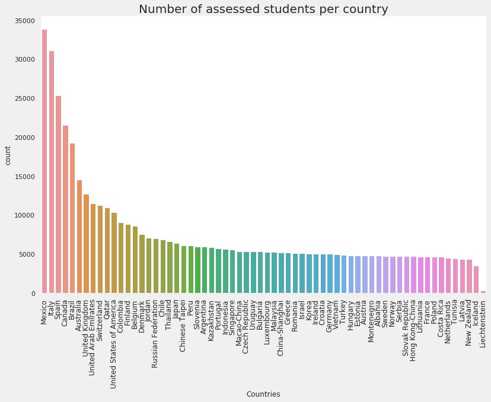

```python
base_color = sns.color_palette()[4]

plt.style.use('fivethirtyeight')
plt.figure(figsize=(12,8))
sns.set(style='white')
sns.countplot(data=df_clean, x = 'Country',order=df_clean['Country'].value_counts().index);
sns.despine(bottom = True, left = True)
plt.xlabel('Countries')
plt.xticks( rotation=90, fontsize='12')
plt.ylabel('count')
plt.title('Number of assessed students per country', fontsize=20)
plt.show()
```

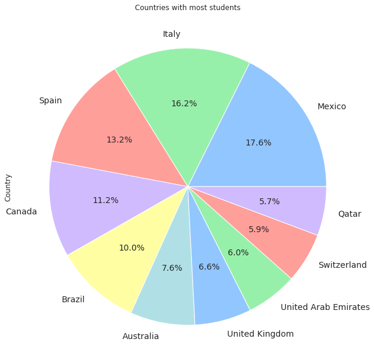

```python
plt.style.use('seaborn-pastel')

p = df_clean.Country.value_counts().head(10).plot.pie(x='Country', autopct='%1.1f%%', rot=2,figsize=(15,10), fontsize = 14);
p.set_title("Countries with most students");
```

## What's the percentage of females/males in the dataset?

- In this visualisation, we examine the percentage of the overall gender distribution.
- It turns out that there are slightly more women than men with a percentage of 1% difference.

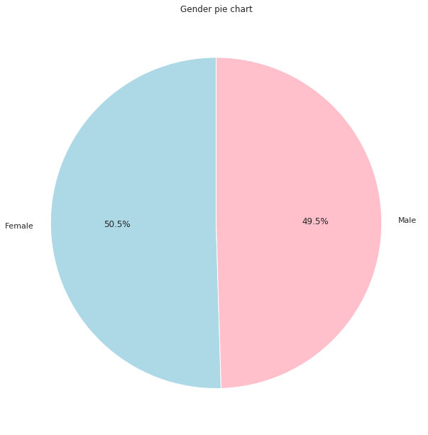

```python
colors = ['lightblue', 'pink']
p = df_clean.Gender.value_counts().head(10).plot.pie(x='Gender', autopct='%1.1f%%', startangle=90,
                                                     colors = colors, rot=2, figsize=(14,10));
p.set_title("Gender pie chart");
plt.ylabel(None);
```

We calculated the difference of males vs females in all countries and we ploted the results in a countplot.  
We can see that there are countries with more female than male and a few one with more male than female.  
We can see that in Mexico there more female than male and this is obvious from the countplot that we created.  
We can also observe that Italy have more male assessed students than female.

## Distribution of scores in math, reading, science

We can see that all the scores are normaly distributed.

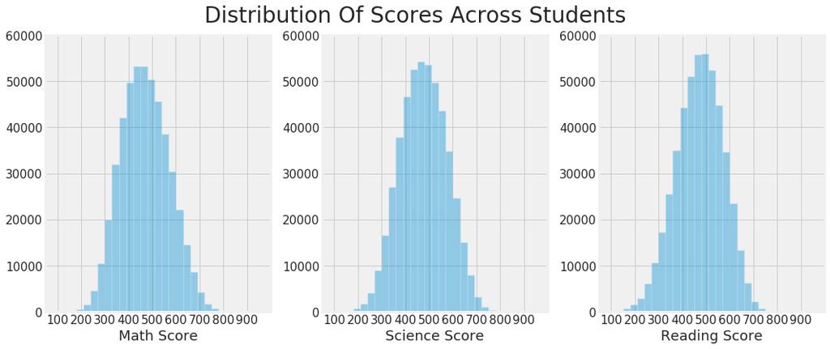

```python
fig, ax = plt.subplots( figsize = [15, 6])
plt.style.use('fivethirtyeight')


#math score distribution
plt.subplot(1, 3, 1)
bin_edges = np.arange(0, df_clean['math_score'].max()+1, 30)
sns.distplot(df_clean['math_score'],  kde = False, bins = bin_edges);
# plot formatting
plt.xlabel('Math Score'.title(), fontsize=18)
plt.ylim(0, 60000)
plt.xlim(50, 1000)
plt.xticks([100,200,300,400,500,600,700,800,900], fontsize=15)
plt.yticks(fontsize=15)

#science score distribution
plt.subplot(1, 3, 2)
bin_edges = np.arange(0, df_clean['science_score'].max()+1, 30)
sns.distplot(df_clean['science_score'], kde = False, bins = bin_edges);
# plot formatting
plt.xlabel('Science Score'.title(), fontsize=18)
plt.ylabel(None)
plt.ylim(0, 60000)
plt.xlim(50, 1000)
plt.xticks([100,200,300,400,500,600,700,800,900], fontsize=15)
plt.yticks(fontsize=15)

#reading score distribution
plt.subplot(1, 3, 3)
bin_edges = np.arange(0, df_clean['science_score'].max()+1, 30)
sns.distplot(df_clean['reading_score'], kde = False, bins = bin_edges);
# plot formatting
plt.xlabel('Reading Score'.title(), fontsize=18)
plt.ylabel(None)
plt.ylim(0, 60000)
plt.xlim(50, 1000)
plt.xticks([100,200,300,400,500,600,700,800,900], fontsize=15)
plt.yticks(fontsize=15)

# set the overall title
plt.suptitle('Distribution of scores across students'.title(), fontsize=28, y=1.04)
plt.tight_layout();
plt.show()
```

As we can see the top performance countries are the Asian countries.  
This is something I would expect to be honest.  
It is interesting to see it plotted as well.  
We can see that Estonia has a really good performance in Science (5th place). Estonia is in top 10 on the 3 subjects. Place 9 on math, place 10 on Reading Score.  
Shanghai is the best on all subjects.  
The top 3 on all subject is Shanghai-Hong Kong-Singapore. All those countries are Asian countries.

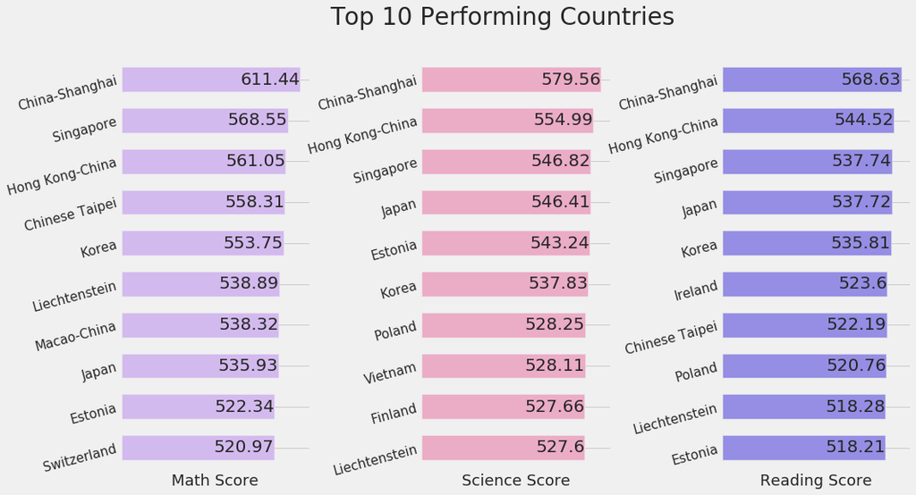

```python
#create average score in each subject by country
top_math=df_clean.groupby('Country')['math_score'].mean().nlargest(10)
top_science=df_clean.groupby('Country')['science_score'].mean().nlargest(10)
top_reading=df_clean.groupby('Country')['reading_score'].mean().nlargest(10)

fig, ax = plt.subplots(figsize = [14.70, 8.27])
plt.subplots_adjust(wspace = 0.6)

#math
plt.subplot(1, 3, 1)
top_math.plot( y='country', kind = 'barh', color = '#d3baee' , width = 0.6)
plt.gca().invert_yaxis()
sns.despine(bottom = True, left = True)
plt.xlabel('Math Score'.title(), fontsize=18)
plt.ylabel(None)
plt.xticks(None)
plt.xticks([])
plt.yticks(fontsize=15, rotation=15)

for index, value in enumerate(top_math):
    plt.text( value, index, str(round(value, 2)), va = 'center', ha='right', fontsize=20)

#science
plt.subplot(1, 3, 2)
top_science.plot( y='country', kind = 'barh', color='#ebacc6', width = 0.6)
plt.gca().invert_yaxis()
sns.despine(bottom = True, left = True)
plt.xlabel('Science Score'.title(), fontsize=18)
plt.ylabel(None)
plt.xticks([])
plt.yticks(fontsize=15, rotation=15)
for index, value in enumerate(top_science):
    plt.text( value, index, str(round(value, 2)), va = 'center', ha='right',fontsize=20)

#reading
plt.subplot(1, 3, 3)
top_reading.plot( y='country', kind = 'barh', color='#958ee4', width = 0.6)
plt.gca().invert_yaxis()
sns.despine(bottom = True, left = True)
plt.xlabel('Reading Score'.title(), fontsize=18)
plt.ylabel(None)
plt.xticks([])
plt.yticks(fontsize=15, rotation=15)
for index, value in enumerate(top_reading):
    plt.text( value, index, str(round(value, 2)), va = 'center', ha='right',fontsize=20)

# set the overall title
plt.suptitle('Top 10 performing countries'.title(), fontsize=28)
plt.show()
```

## Bivariate exploration

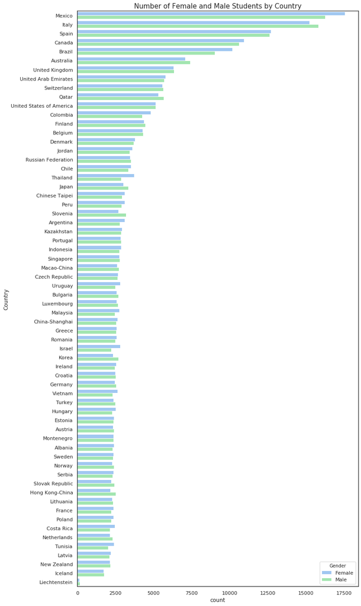

```python
plt.style.use('seaborn-pastel')
sns.set_context("notebook")

order= df_clean['Country'].value_counts().index

plt.figure(figsize=[10,22])
sns.countplot(data=df_clean, y='Country', order=order, hue='Gender')
plt.title('Number of Female and Male Students by Country',size=15);
plt.savefig('gender_distribution.png', bbox_inches='tight')
```

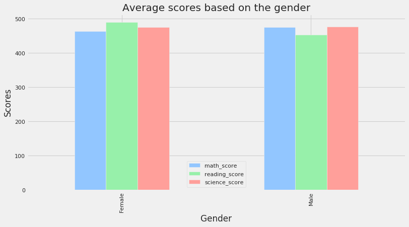

```python
plt.style.use('seaborn-pastel')

res = df_clean.groupby(['Gender']).mean()[['math_score', 'reading_score', 'science_score']]
ax = res.plot.bar(figsize=(12,6));
plt.ylabel('Scores')
plt.title('Average scores based on the gender');
```

## Proporition of Female students by country

In this plot we can see the difference of females in the countries.  
We can see that in some countries there are more female than male students.

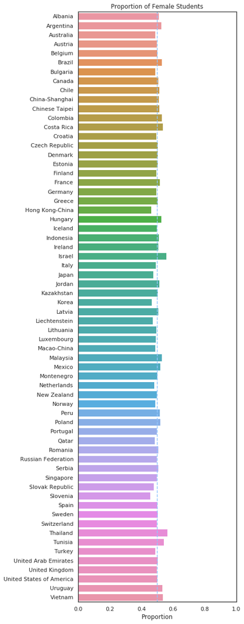

```python
dummies = pd.get_dummies(df_clean['Gender'])
df_clean = pd.concat([df_clean, dummies], axis=1)

gender = df_clean.groupby("Country").Gender.value_counts(normalize=True).rename("Proportion").reset_index()

#sort by proportions
gender = gender.loc[gender["Gender"] == "Female",:].sort_values("Proportion")

plt.figure(figsize = [5,20])

g = sns.barplot(x="Proportion", y="Country", data = gender)
g.axvline(0.5, ls='--')
g.set_xlim(0,1)
plt.title("Proportion of Female Students")
plt.ylabel(None);
```

## Proporition of Male students by country

Now, let's plot the proportion of Male Students.

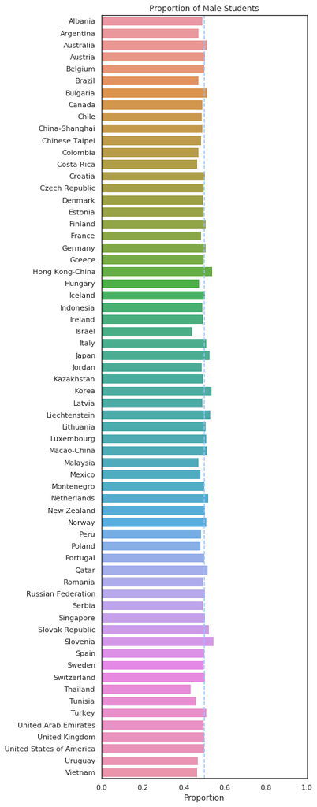

```python
gender = df_clean.groupby("Country").Gender.value_counts(normalize=True).rename("Proportion").reset_index()

#sort by proportions
gender = gender.loc[gender["Gender"] == "Male",:].sort_values("Proportion")

plt.figure(figsize = [5,20])

g = sns.barplot(x="Proportion", y="Country", data = gender)
g.axvline(0.5, ls='--')
g.set_xlim(0,1)
plt.title("Proportion of Male Students")
plt.ylabel(None);
```

Student's interest in math vs Parent's interest in math

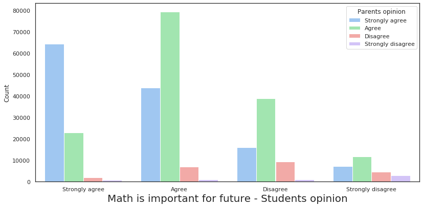

```python
plt.figure(figsize=(12,6))
sns.countplot(data = df_clean, x = 'math_imprtnt_future_student', hue = 'math_imprtnt_future_parents')
plt.legend(title='Parents opinion')
plt.ylabel('Count');
plt.xlabel('Math is important for future - Students opinion', fontsize=20);
```

## Multivariate Exploration

Country vs Ave score vs Gender

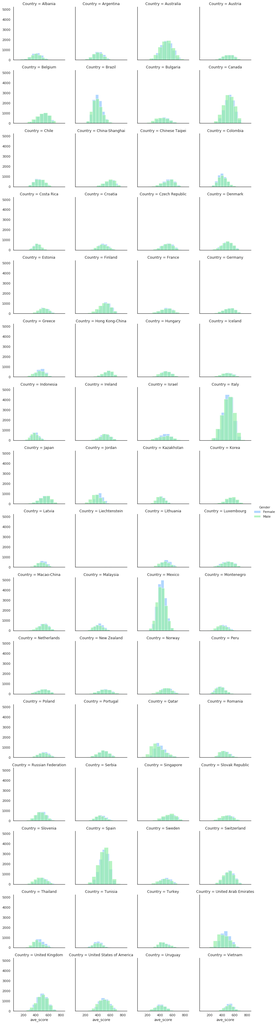

```python
g = sns.FacetGrid(data = df_clean, col = 'Country', hue='Gender', col_wrap=4)
g.map(plt.hist, 'ave_score',  alpha = 0.7 ).add_legend();
```

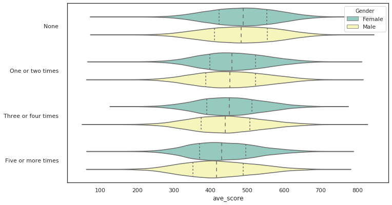

```python
plt.figure(figsize=(10,6))
sns.violinplot(y='late_for_sch', x='ave_score', data = df_clean, inner = 'quartile', palette='Set3', hue='Gender', height=8, aspect=.7);
plt.ylabel(None);
```

As Greece is my country I would like to do more eploration of the greek data.  
I will plot a heatmap to find any correlations between the variables.

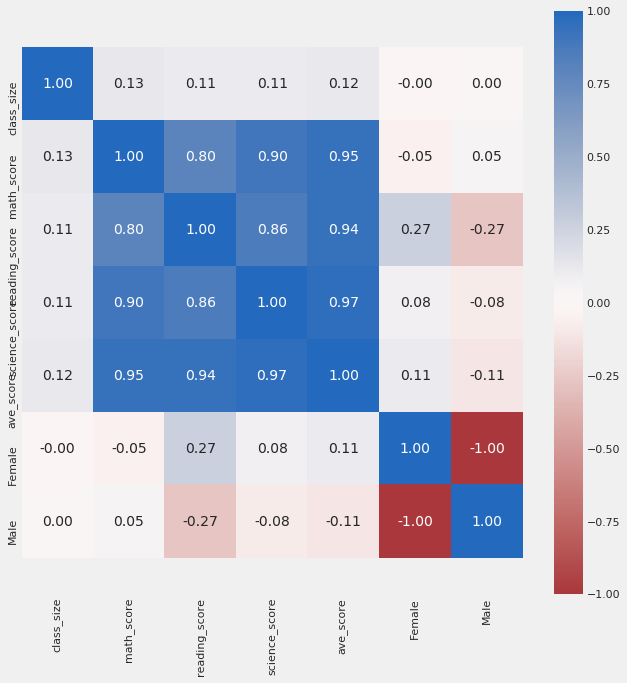

```python
df_greece=df_clean.loc[df_clean["Country"] == "Greece",]
#make correlation matrix
corrMatrix_gr = df_greece.corr()

#plot heatmap of features correlated
plt.figure(figsize = [10,10])

ht = sns.heatmap(corrMatrix_gr, annot = True,cmap = 'vlag_r',fmt = '.2f',center = 0)
ht.set_ylim(len(corrMatrix_gr)+0.5, -0.5);
```

## Late for school vs Gender vs Ave score for Greece

We plot the violin plot with the Greece data and we see that the result is not the same.  
We observe a big difference for the males who are late 5 or more times.

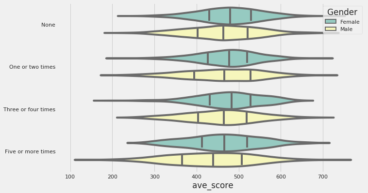

```python
plt.figure(figsize=(10,6))
sns.violinplot(y='late_for_sch', x='ave_score', data = df_greece, inner = 'quartile', palette='Set3', hue='Gender', height=8, aspect=.7);
plt.ylabel(None);
```